# Befolkningsutvecklingen i Mora

Befolkningsutvecklingen i Mora  
- en kort analys

Rapporten är skapad av Samhällsanalys, Region Dalarna  
Senast uppdaterad: 2024-10-05

# Sammanfattning

Syftet med den här korta analysen är att undersöka Moras befolkningsutveckling. Ett antal viktiga slutsatser sammanfattas här:

- Nedgången i Moras folkmängd år 2023, jämfört med åren innan, beror på att såväl flyttnettot som födelsenettot minskat jämfört med åren innan.
- Det föddes färre barn i Mora 2023, jämfört med åren innan. Detta är i linje med en större trend i samhället, då barnafödandet per kvinna i Sverige 2023 var det lägsta som har uppmätts.
- En stramare nationell migrationspolitik gör att färre invandrar till Sverige än tidigare, vilket även påverkar inflyttningen till Mora.
- Många unga vuxna mellan 20 och 29 år flyttade från Mora till andra delar av Sverige under 2023.

För mer info om statistiken, klicka på rutan nedan:

**Mer information om statistiken**

I folkmängden som SCB publicerar ingår personer som är folkbokförda i landet. För att den som flyttar till Sverige ska bli folkbokförd ska personen ha för avsikt och rätt att stanna i Sverige i minst ett år. För personer som inte är medborgare i ett EU-land innebär det att det krävs ett uppehållstillstånd som gäller minst 12 månader för att bli folkbokförd. Till följd av Rysslands invasion av Ukraina den 24 februari 2022 har Europeiska unionen (EU) beslutat att aktivera massflyktsdirektivet, vilket innebär att personer från Ukraina utan individuell prövning ska erbjudas tidsbegränsat uppehålls- och arbetstillstånd inom EU. Personer som får uppehållstillstånd enligt massflyktsdirektivet ska i regel inte bli folkbokförda och ingå i den officiella befolkningsstatistiken. Läs mer [här](https://www.scb.se/hitta-statistik/statistik-efter-amne/befolkning/befolkningens-sammansattning/befolkningsstatistik/produktrelaterat/Fordjupad-information/statistik-om-invandring---fragor-och-svar/).

Under 2023 inledde Skatteverket ett arbete med att granska registret över folkbokförda. Det förde med sig att SCB avregistrerade flera tusen folkbokförda personer som visade sig inte längre bo i Sverige. I folkbokföringen har dessa registrerats som utvandrade till okänt utvandringsland. Läs mer [här](https://www.scb.se/pressmeddelande/sverige-gar-mot-lagsta-befolkningsokningen-pa-manga-ar/).

All data som används i rapporten är offentlig och finns under kategorin befolkning i SCB:s [Statistikdatabas](https://www.statistikdatabasen.scb.se/pxweb/sv/ssd/). Där finns även data för exempelvis befolkningsutvecklingen under 2024 på månadsbasis, något som inte behandlas i denna rapport.

# 1 Hur har befolkningen förändrats?

I Mora har folkmängden ökat sedan slutet på 1960-talet, från ca 17 200 invånare år 1968 till ungefär 20 500 invånare år 2023. Den största ökningen skedde under 1970- och 1980-talen, då befolkningen ökade mer eller mindre varje år. Därefter skedde en minskning efter finanskrisen på 1990-talet, innan befolkningstillväxten återigen tog fart i samband med flyktingkrisen (åren runt 2016). Under 2023 minskade folkmängden med 143 personer, vilket är den största minskningen sedan slutet på 1990-talet.

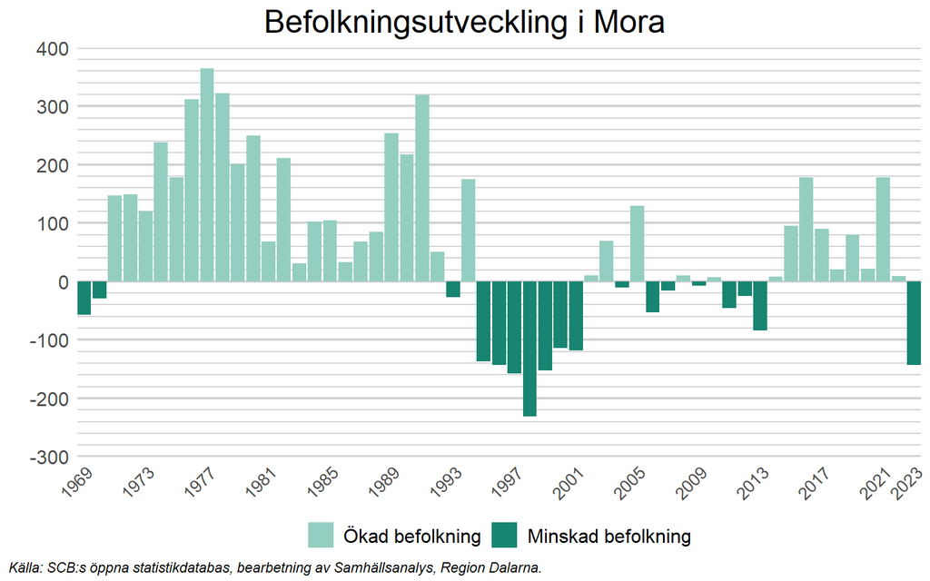

I fortsättningen av denna korta analys delas befolkningsutveckling upp i dess komponenter, födelsenetto, dvs. nettot av födda och döda, och flyttnetto, dvs. nettot av inrikes och utrikes flyttar.

# 2 Födelsenetto

Under 2023 avled 276 personer boende i Mora, vilket är den högsta siffran sedan tidigt 1990-tal. Man bör dock ha i åtanke att medelåldern i samhället kontinuerligt ökar över tid, vilket härrör till utveckling inom det medicinska området.

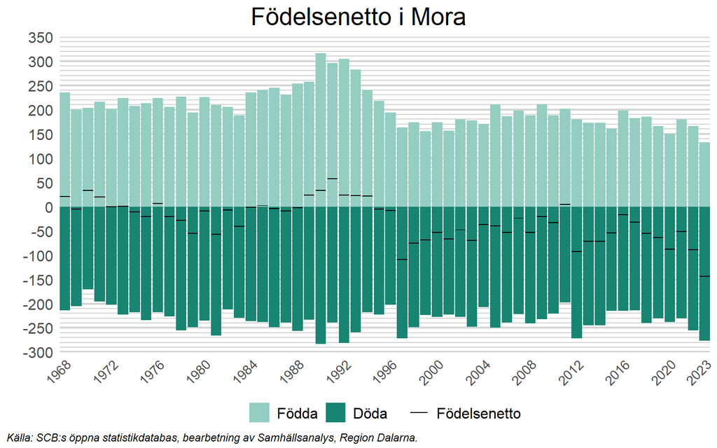

# 3 Flyttnetto

Den andra komponenten som styr befolkningsutvecklingen är det så kallade flyttnettot. Detta kan i sin tur delas upp i två komponenter, inrikes och utrikes flyttar. I det här avsnittet är fokus först på flyttnettot, innan de två komponenterna undersöks.

Nettot mellan antalet personer som flyttar till och från Mora varierar relativt mycket mellan åren, men har varit positivt under stora delar av 2000-talet. Många flyttade till kommunen under åren runt flyktingkrisen (2015-2016), men även under början av 2000-talet var inflyttningen stor (netto). På senare år har flyttnettot varit positivt med en tydlig topp 2021, men 2023 var nettot negativt (-10 personer) för första gången på 10 år.

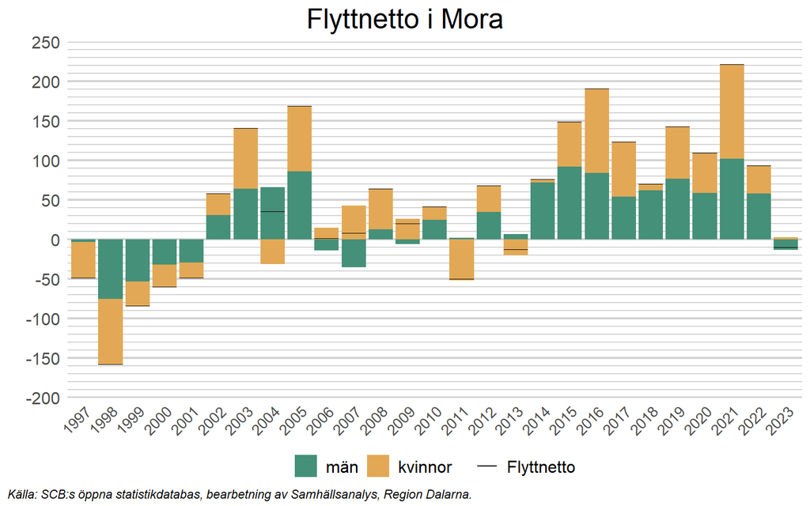

## 3.1 Utrikes flyttnetto

Som berördes i föregående avsnitt, flyttade många till Mora under åren runt flyktingkrisen (2015-2016), vilket till stor del kan förklaras av att invandringen då var stor. I slutet av 1990-talet var invandringen ofta väldigt låg och till och med negativ under vissa år (fler utvandrade än invandrade), men därefter ökade invandringen med en topp 2015. Därefter har invandringen gradvis minskat men låg på förhållandevis höga nivåer fram till 2022. Under 2023 var det utrikes flyttnettot 44 personer, det lägsta nettot sedan 2013. En liten del av minskningen kan förklaras av att Skattemyndigheten under 2023 påbörjade en avregistrering av utvandrade (se informationsrutan under avsnittet introduktion ovan), men den viktigaste anledning är sannolikt en stramare nationell migrationspolitik.

Generellt invandrar ungefär lika många kvinnor och män till Mora.

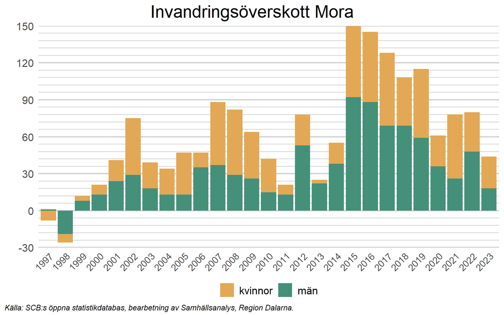

## 3.2 Inrikes flyttnetto

Det inrikes flyttnettot varierar relativt mycket mellan åren i Mora, med omväxlande perioder av positivt och negativt flyttnetto. Från 2019 och några år framåt var dock nettot positivt med en topp 2021, då befolkningen ökade med närmare 150 personer till följd av inrikes flyttar. Detta kan möjligtvis vara en effekt kopplad till Corona-pandemin, då nettot var avsevärt mycket lägre 2020 (människor fördröjde eventuellt sina flyttar). År 2023 flyttade 54 personer netto från kommunen inrikes, vilket var det första negativa nettot sedan 2018.

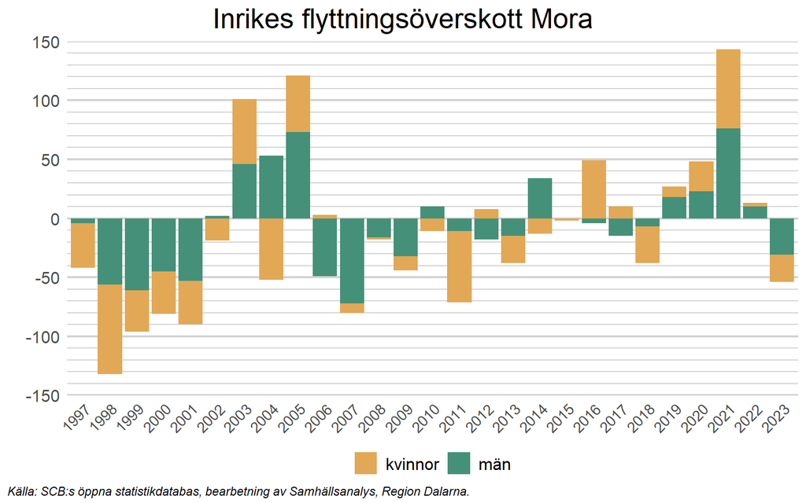

För att bättre förstå vilka som flyttar till och från kommunen inrikes, delas de som flyttar härnäst upp efter ålder. Normalt är personer mest benägna att flytta till en annan ort när de är i 20-års åldern, innan flyttandet gradvis avtar.

### 3.2.1 Uppdelat på ålder

I Mora är det framförallt personer i åldersgruppen 20-29 år som flyttar från kommunen till andra delar av Sverige, medan det omvända gäller för de flesta andra åldersgrupperna i diagrammet nedan. Med undantag för personer över 60 år, minskade dock flyttnettot i alla åldersgrupper under 2023 jämfört med året innan.

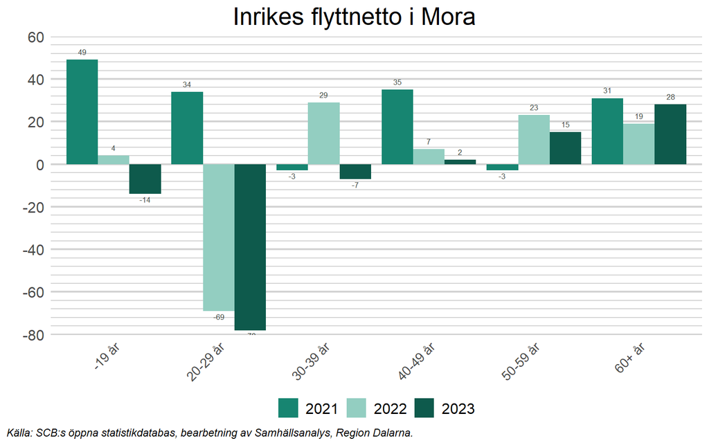

Om fokus enbart läggs på åldersgruppen 20-29 år, blir det tydligt att det sedan slutet av 1990-talet i praktiken alltid flyttat fler unga vuxna från än till kommunen inrikes. Historiskt varierar det inrikes flyttnettot i åldersgruppen mellan åren, vilket exempelvis kan bero på att olika årskullar av barn är olika stora. Under 2023 flyttade 78 personer netto från kommunen inrikes, vilket är något fler än året innan.

Även i Dalarna som helhet flyttade fler i åldersgruppen ut än in under 2023.

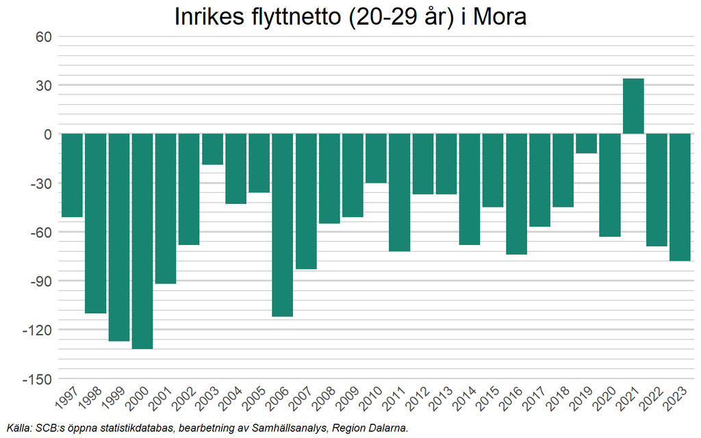

### 3.2.2 Uppdelat på bakgrund

För att ytterligare förtydliga vilka som flyttar till och från Mora inrikes, delas de i detta avsnitt upp efter sin bakgrund, inrikes eller utrikes födda.

En del av de personer som invandrade till Mora under framförallt 2016, verkar ha flyttat därifrån sedan dess, då det inrikes flyttnettot i gruppen utrikes födda har varit negativt under varje år sedan 2017.

Bland inrikes födda är variationen mellan åren relativt stor, men tydligt är att förhållandevis många inrikes födda har flyttat till kommunen på senare år. Framförallt skedde en stor inflyttning under 2021. År 2023 flyttade 7 inrikes födda personer netto från kommunen, vilket är det första negativa nettot sedan 2018.

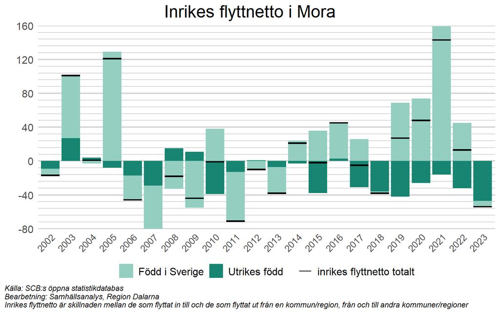

I nästa avsnitt är fokus istället på framtiden. Hur kommer Moras folkmängd att utvecklas fram till 2033?

# 4 Vad händer i framtiden?

För en djupare förståelse runt hur SCB gör befolkningsprognoser, se motsvarande avsnitt i rapporten för hela Dalarnas län. Det viktigaste att ha i åtanke är att ingen hänsyn tas i prognoserna till planerat bostadsbyggande, företagsetableringar eller andra framtida mål och förutsättningar som kommunerna har i sina planer.

I diagrammet nedan visas befolkningsutvecklingen i Mora fram till 2033 enligt SCB:s senaste prognos (juni 2024), uppdelat på åldersgrupper. Ett par tydliga trender kan utläsas i diagrammet:

- Moras befolkning prognostiseras att minska med ungefär 500 personer fram till 2033, vilket är en större minskning än vid föregående prognos. I den prognosen, som släpptes 2022, prognostiserades en minskning på ungefär 180 personer fram till 2033, jämfört med 2021 (se [SCB](https://www.statistikdatabasen.scb.se/pxweb/sv/ssd/START__BE__BE0401__BE0401B/BefProgRegFakN22/table/tableViewLayout1/)).
- Den största minskningen sker i åldersgruppen 0-19 år, som prognostiseras minska med ungefär 600 personer.
- I åldergruppen 80+ förväntas befolkning istället att öka med ca 740 personer fram till 2033. Detta hänger sannolikt samman med att den förväntade livslängden fortsätter öka och att den stora gruppen “baby-boomers” börjar komma upp i 80-års åldern.

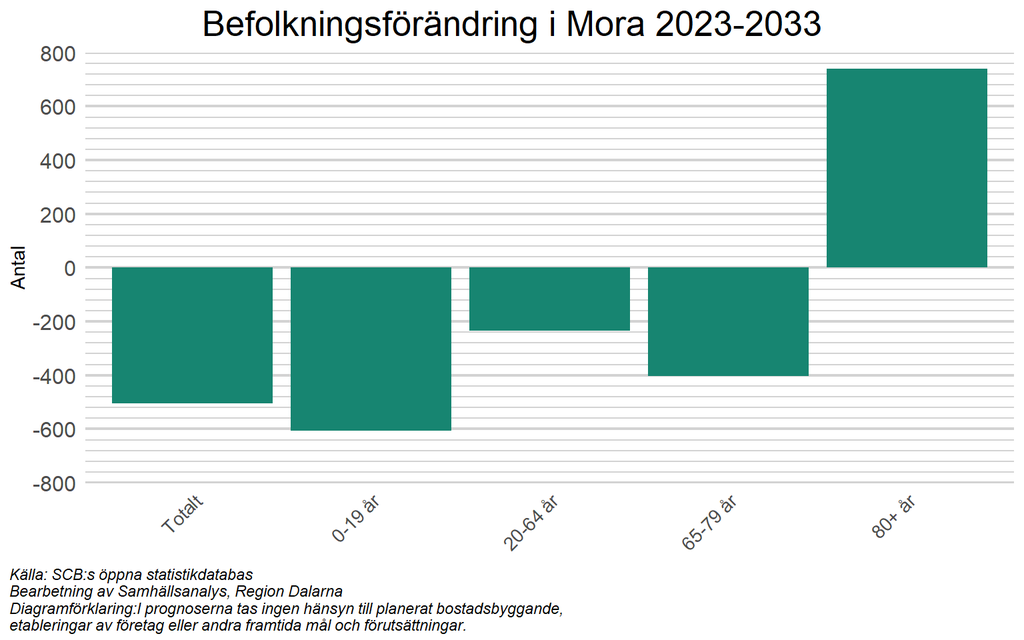